# 盈利模式

#### 2.2.1.4 40期

```r
##40期为标准
n40 <- llply(41:nrow(smppp), function(i) {
  ii <- i - 40
  dx = glm(as.numeric(大小)~总值-1, family=poisson, data=smppp[c(ii:i),]) %>%
    coef %>% exp
  dx <- dx/sum(1 + dx)
  ds = glm(as.numeric(单双)~总值-1, family=poisson, data=smppp[c(ii:i),]) %>%
    coef %>% exp
  ds <- ds/sum(1 + ds)
  data.frame(dx, ds) %>%
    rename(`开大` = dx, `开单` = ds) %>%
    mutate(`开小` = 1- `开大`, `开双` = 1- `开单`) %>%
    select('开大', '开小', '开单', '开双') %>%
    data.frame(smppp[i,], .)
}) %>% bind_rows %>% tbl_df

n40 %>%
  kable(caption = '40期为标准') %>%
  kable_styling(bootstrap_options = c('striped', 'hover', 'condensed', 'responsive')) %>%
  scroll_box(width = '100%', height = '400px')
```

```r
n40[c('开大', '开小', '开单', '开双')] %>%
  colMeans %>% t %>%
  kable(caption = '40期为标准') %>%
  kable_styling(bootstrap_options = c('striped', 'hover', 'condensed', 'responsive'))
```

#### 2.2.1.5 50期

```r
##50期为标准
n50 <- llply(51:nrow(smppp), function(i) {
  ii <- i - 50
  dx = glm(as.numeric(大小)~总值-1, family=poisson, data=smppp[c(ii:i),]) %>%
    coef %>% exp
  dx <- dx/sum(1 + dx)
  ds = glm(as.numeric(单双)~总值-1, family=poisson, data=smppp[c(ii:i),]) %>%
    coef %>% exp
  ds <- ds/sum(1 + ds)
  data.frame(dx, ds) %>%
    rename(`开大` = dx, `开单` = ds) %>%
    mutate(`开小` = 1- `开大`, `开双` = 1- `开单`) %>%
    select('开大', '开小', '开单', '开双') %>%
    data.frame(smppp[i,], .)
}) %>% bind_rows %>% tbl_df

n20 %>%
  kable(caption = '50期为标准') %>%
  kable_styling(bootstrap_options = c('striped', 'hover', 'condensed', 'responsive')) %>%
  scroll_box(width = '100%', height = '400px')
```

```r
n50[c('开大', '开小', '开单', '开双')] %>%
  colMeans %>% t %>%
  kable(caption = '50期为标准') %>%
  kable_styling(bootstrap_options = c('striped', 'hover', 'condensed', 'responsive'))
```

### 2.2.2 模型比较

```r
md <- list(n760 = n760,
     n20 = n20[c('开大', '开小', '开单', '开双')] %>% colMeans,
     n30 = n30[c('开大', '开小', '开单', '开双')] %>% colMeans,
     n40 = n40[c('开大', '开小', '开单', '开双')] %>% colMeans,
     n50 = n50[c('开大', '开小', '开单', '开双')] %>% colMeans) %>% bind_rows
md <- data.frame(.id = c('n760', 'n20', 'n30', 'n40', 'n50'), md) %>% tbl_df

md %>%
  kable(caption = '模型比较') %>%
  kable_styling(bootstrap_options = c('striped', 'hover', 'condensed', 'responsive'))
```

## 2.3 盈利模式

### 2.3.1 套彩

**赔率与优惠**

以平台欧赔`1.98`来说，亚赔`0.98`等于1.0204082，会员平均投1.0204082元才能赢1元。

我们平台最新活动彩金介绍：

1. 周一到周五转账彩金2%送，次日自动到账。
2. 周六，周日转账彩金3%送，当天未下注前找在线客服领取。
3. 每日嘉奖零点后自己手动领取，在平台的活动中心每日嘉奖里面领取。
4. 晋级奖励最高58888 在平台活动中心晋级奖励里面领取。
5. 官方授权聊天室福利来袭 红包每天100万 整点发放领取最高1888。
6. 余额宝活期理财，每1万本金存入余额宝转出余额可以直接领取1000彩金。
7. 签到满勤奖，只要一星期内满足存款条件，星期一即可领取最高5888元奖励

提醒：每笔充值金额达到200元以上，方可领取转卡加赠彩金（不限笔数）

### 2.3.2 投注模式

**必胜攻略，真实稳赚** 你一定行，你一定赢

#### 2.3.2.1 秘诀1：增倍方式

以10起押为例,10,20,40,80,160,320,640依次下去，反正一把就要把前面输的赢回来，准备最少6期本金。当然也要视自己的情况押，比如5,10,20,40 起押，倍增多少自己可以算。

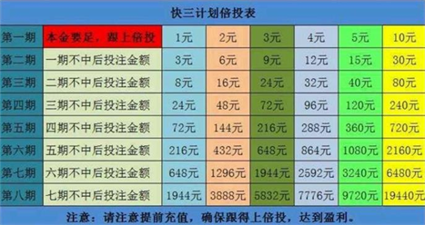

有兴趣索取个倍投表电子表格，加菜菜QQ：2849108450

#### 2.3.2.2 秘诀2：押注方式

进行游戏后谁赢就押谁。大赢了，就押大。 如果小赢了，那就跟着押小;然后就一直交替着押，这样押的目的是避免出10连，甚至20连亏。

#### 2.3.2.3 秘诀3：走势规律

口诀中的一见跳跟跳;不管什么时候玩，我们都要学会观察走势规律，即大小大小大小;这样单跳的情况，一旦出现时，我们就要顺势而为出大买小，前面的方法我们都先不要管，一直到不再单跳为止。

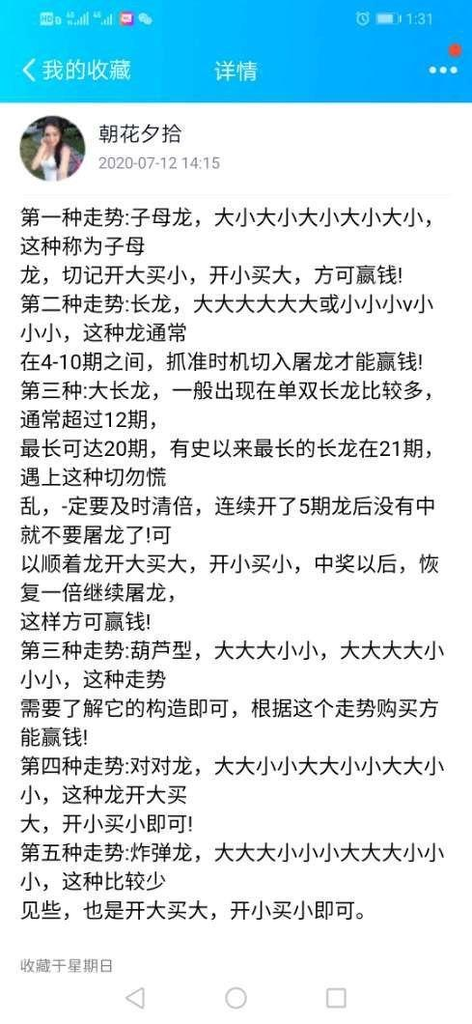

#### 2.3.2.4 秘诀4：雪球方式

最简单最实用的方法，需要听老师详细讲解。

### 2.3.3 线下活动

#### 2.3.3.1 大额彩金

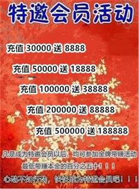

彩金送得多，名额有限，相信其它平台都没有呢。

#### 2.3.3.2 包赔活动

亏得多的会员可以报名预约带亏了包赔，名额有限，相信其它平台都没有呢。

#### 2.3.3.3 带赚活动

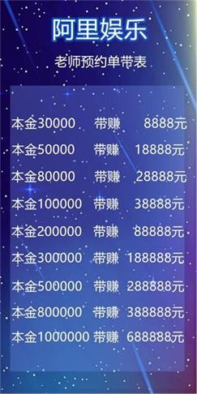

无论盈亏的会员，亏得多的会员更需要报名预约赢回钱，名额有限，相信其它平台都没有呢。

### 2.3.4 当代理

[figure not shown]

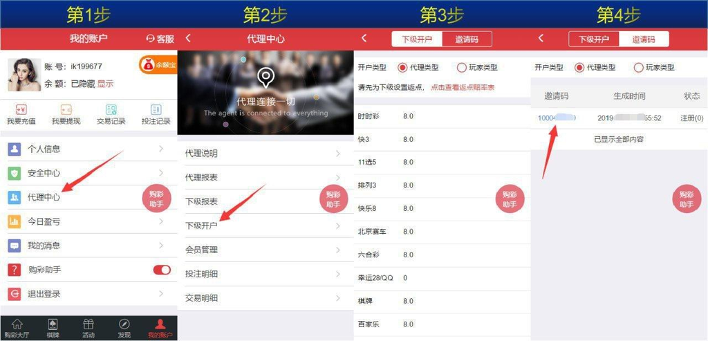

以上乃激活邀请码的教程。

当代理挣返点也是适合打工一族业余兼职、宝妈、学生，尤其是生意人人脉广阔，挣钱方便生意周转。

# 3 结论

## 3.1 总结

以上总结，会员可以到我们平台通过不同盈利模式挣钱的呢。

```r
## 改进

## https://stackoverflow.com/a/45344291
require('RSelenium')
require('rvest')
#require('wdman')
#require('webshot')
require('decryptr')

## 网址
## 登录网址
lnk <- 'https://m.a80802.com:8760/login'
## 彩种一栏
lnkcz <- 'https://m.cjezllpcecbm.com/allLottery/?source=lottery'
## 1分快三
lnk1k3 <- 'https://m.cjezllpcecbm.com/history/K3/OG1K3/?source=lottery'
## 3分快三
lnk3k3 <- 'https://m.cjezllpcecbm.com/history/K3/OG3K3/?source=lottery'

#lnk1k3 %>%
#  read_html %>%
#  html_nodes(xpath = '//*[@id="scrollContainer"]/div[2]') %>%
#  html_table()

## 打开隐藏浏览器
pDrv <- phantomjs(port = 4567L, check = FALSE, verbose = FALSE)
remDr <- remoteDriver(browserName = 'phantomjs', port = 4567L)
remDr$open(silent = TRUE)

## 浏览网站
remDr$navigate(lnk1k3)

## 输入账号
webElem <- remDr$findElement(using = 'xpath', value = '//*[@id="app"]/div/div[1]/div[3]/div/table/tbody/tr[1]/td[2]/input')
webElem$clickElement()
webElem$sendKeysToElement(list('leiou004', key = 'enter'))

## 输入密码
webElem <- remDr$findElement(using = 'xpath', value = '//*[@id="app"]/div/div[1]/div[3]/div/table/tbody/tr[2]/td[2]/input')
webElem$clickElement()
webElem$sendKeysToElement(list('leiou123', key = 'enter'))

## 验证码
## https://github.com/decryptr/decryptr
## https://rpubs.com/johndharrison/14707
webElem <- remDr$findElement(using = 'xpath', value = '//*[@id="geetest"]/div/div[2]/div[1]/div[3]')
webElem$clickElement()
webElem$sendKeysToElement(list(key = 'enter'))
#webElem$switchToFrame('div.geetest_popup_box')

#if (!require(devtools)) install.packages('devtools')
#devtools::install_github('decryptr/decryptr')





##样本数据只是减低投资风险，采集实时数据才能证实有效性。
```